Team members:

> [Mykyta Yahoda](https://github.com/yagodanr)

> [Oleksandr Lykhanskyi](https://github.com/LMTMARS)

> [Ivan Zarytskyi](https://github.com/ivan-in-a-nutshell)

```r
library(pacman)
p_load(dplyr)
p_load(lubridate)
p_load(ggplot2)
p_load(fitdistrplus)
p_load(performance)
```

# Dataset processing

Dataset is a number web-scrappped csv datasets from Transfermarkt to learn more follow the [link](https://www.kaggle.com/datasets/davidcariboo/player-scores/data?select=appearances.csv)

## goals dataset

```r
game_events <- read.csv("./player-scores/game_events.csv")
players     <- read.csv("./player-scores/players.csv")
clubs       <- read.csv("./player-scores/clubs.csv")
games       <- read.csv("./player-scores/games.csv")
```

```r
game_events <- dplyr::select(game_events, !c(game_event_id, player_in_id, player_assist_id))
games       <- dplyr::select(games, game_id, spectators=attendance,
                        home_club_name, away_club_name,
                        home_club_goals, away_club_goals)
players     <- dplyr::select(players, player_id, player=name, date_of_birth)
clubs       <- dplyr::select(clubs, club_id, player_club=name)
```

```r
head(players)
```

```
##   player_id             player       date_of_birth
## 1        10     Miroslav Klose 1978-06-09 00:00:00
## 2        26 Roman Weidenfeller 1980-08-06 00:00:00
## 3        65   Dimitar Berbatov 1981-01-30 00:00:00
## 4        77              Lúcio 1978-05-08 00:00:00
## 5        80         Tom Starke 1981-03-18 00:00:00
## 6       109               Dedê 1978-04-18 00:00:00
```

```r
game_events <- merge(game_events, players, by = "player_id", all = TRUE)
game_events <- merge(game_events, clubs, by = "club_id", all = TRUE)
game_events <- merge(game_events, games, by = "game_id", all = TRUE)
```

```r
# summary(game_events)
game_events <- game_events %>% filter(!is.na(player))
game_events <- arrange(game_events, date, minute)
head(game_events, 100)
```

```
##     game_id club_id player_id       date minute          type
## 1   2231978     853     38004 2012-07-03     51         Goals
## 2   2234412   10694    120518 2012-07-03     58         Goals
## 3   2231978     853     38004 2012-07-03     90         Goals
## 4   2235772   18506     54581 2012-07-05      2         Goals
## 5   2235542    1101    113039 2012-07-05      5         Goals
## 6   2235769   11907     95431 2012-07-05     13         Cards
## 7   2235542    1101    113039 2012-07-05     24         Goals
## 8   2235542    1101    113039 2012-07-05     26         Goals
## 9   2235545     317     30667 2012-07-05     28         Goals
## 10  2235771    4807    150846 2012-07-05     28         Cards
## 11  2235545     317     30667 2012-07-05     29         Goals
## 12  2235541    3654     76085 2012-07-05     35         Cards
## 13  2235769   11907    206544 2012-07-05     42         Goals
## 14  2235772   18506     54581 2012-07-05     45         Cards
```

[output cut: 490 more lines]

```r
summary(game_events)
```

```
##     game_id           club_id         player_id           date
##  Min.   :2211607   Min.   :     1   Min.   :     10   Length:914319
##  1st Qu.:2604316   1st Qu.:   294   1st Qu.:  61891   Class :character
##  Median :3199462   Median :   865   Median : 167291   Mode  :character
##  Mean   :3219919   Mean   :  3533   Mean   : 222231
##  3rd Qu.:3839181   3rd Qu.:  2578   3rd Qu.: 329517
##  Max.   :4572898   Max.   :121775   Max.   :1391239
##  NA's   :7390      NA's   :7390
##      minute           type           description           player
##  Min.   : -1.00   Length:914319      Length:914319      Length:914319
##  1st Qu.: 46.00   Class :character   Class :character   Class :character
##  Median : 67.00   Mode  :character   Mode  :character   Mode  :character
##  Mean   : 62.05
##  3rd Qu.: 80.00
##  Max.   :120.00
##  NA's   :7390
##  date_of_birth      player_club          spectators     home_club_name
##  Length:914319      Length:914319      Min.   :    1    Length:914319
##  Class :character   Class :character   1st Qu.: 5461    Class :character
##  Mode  :character   Mode  :character   Median :14158    Mode  :character
##                                        Mean   :19824
##                                        3rd Qu.:29100
##                                        Max.   :99354
##                                        NA's   :119383
##  away_club_name     home_club_goals  away_club_goals
##  Length:914319      Min.   : 0.000   Min.   : 0.000
##  Class :character   1st Qu.: 1.000   1st Qu.: 0.000
##  Mode  :character   Median : 1.000   Median : 1.000
##                     Mean   : 1.712   Mean   : 1.409
##                     3rd Qu.: 2.000   3rd Qu.: 2.000
##                     Max.   :17.000   Max.   :19.000
##                     NA's   :7390     NA's   :7390
```

```r
goals   <- game_events[game_events$type=="Goals", ]
head(goals)
```

```
##   game_id club_id player_id       date minute  type
## 1 2231978     853     38004 2012-07-03     51 Goals
## 2 2234412   10694    120518 2012-07-03     58 Goals
## 3 2231978     853     38004 2012-07-03     90 Goals
## 4 2235772   18506     54581 2012-07-05      2 Goals
## 5 2235542    1101    113039 2012-07-05      5 Goals
## 7 2235542    1101    113039 2012-07-05     24 Goals
##                                                                      description
## 1             , Header, 1. Tournament Goal Assist: , Cross, 1. Tournament Assist
## 2   , Right-footed shot, 1. Tournament Goal Assist: , Pass, 1. Tournament Assist
## 3 , Right-footed shot, 2. Tournament Goal Assist: , Header, 1. Tournament Assist
## 4   , Right-footed shot, 1. Tournament Goal Assist: , Pass, 1. Tournament Assist
## 5                                                   , 1. Tournament Goal Assist:
## 7    , Left-footed shot, 2. Tournament Goal Assist: , Pass, 1. Tournament Assist
##              player       date_of_birth player_club spectators home_club_name
## 1  Aurélien Joachim 1986-08-10 00:00:00        <NA>       1070
## 2  Ilya Aleksievich 1991-02-10 00:00:00        <NA>        650
## 3  Aurélien Joachim 1986-08-10 00:00:00        <NA>       1070
## 4 Ilija Nestorovski 1990-03-12 00:00:00        <NA>        410
## 5       Niklas Hult 1990-02-13 00:00:00        <NA>       2653
## 7       Niklas Hult 1990-02-13 00:00:00        <NA>       2653
##   away_club_name home_club_goals away_club_goals
## 1                              7               0
## 2                              0               6
## 3                              7               0
## 4                              2               2
## 5                              8               0
## 7                              8               0
```

## appearances dataset

```r
appearances <- read.csv("./player-scores/appearances.csv")
appearances <- merge(appearances, clubs, by.x = "player_club_id", by.y = "club_id")
appearances <- merge(appearances, players, by.x = "player_id", by.y = "player_id")
appearances <- dplyr::select(appearances, player_club_id, game_id, player_id,
                      date, player=player_name, player_club,
                      minutes_played,yellow_cards, red_cards, goals, assists,
                      date_of_birth)
appearances <- appearances %>%
  mutate(
    dob = as.Date(date_of_birth),
    age_at_match = as.numeric(difftime(as.Date(date), dob, units = "days")) / 365.25
  )
```

```r
head(appearances)
```

```
##   player_club_id game_id player_id       date         player
## 1            398 2359558        10 2014-05-05 Miroslav Klose
## 2            398 2301913        10 2013-04-11 Miroslav Klose
## 3            398 2251440        10 2012-12-22 Miroslav Klose
## 4            398 2359399        10 2014-01-19 Miroslav Klose
## 5            398 2251318        10 2012-09-30 Miroslav Klose
## 6            398 2251443        10 2013-01-13 Miroslav Klose
##                     player_club minutes_played yellow_cards red_cards goals
## 1 Società Sportiva Lazio S.p.A.             17            0         0     0
## 2 Società Sportiva Lazio S.p.A.             34            1         0     0
## 3 Società Sportiva Lazio S.p.A.             90            0         0     0
## 4 Società Sportiva Lazio S.p.A.             90            1         0     0
## 5 Società Sportiva Lazio S.p.A.             90            1         0     0
## 6 Società Sportiva Lazio S.p.A.             87            0         0     0
##   assists       date_of_birth        dob age_at_match
## 1       0 1978-06-09 00:00:00 1978-06-09     35.90418
## 2       0 1978-06-09 00:00:00 1978-06-09     34.83915
## 3       0 1978-06-09 00:00:00 1978-06-09     34.53799
## 4       1 1978-06-09 00:00:00 1978-06-09     35.61396
## 5       1 1978-06-09 00:00:00 1978-06-09     34.31075
## 6       0 1978-06-09 00:00:00 1978-06-09     34.59822
```

```r
summary(appearances)
```

```
##  player_club_id      game_id          player_id           date
##  Min.   :     3   Min.   :2211607   Min.   :     10   Length:1698636
##  1st Qu.:   289   1st Qu.:2589001   1st Qu.:  58345   Class :character
##  Median :   825   Median :3080786   Median : 149237   Mode  :character
##  Mean   :  3128   Mean   :3166072   Mean   : 209630
##  3rd Qu.:  2439   3rd Qu.:3621588   3rd Qu.: 306024
##  Max.   :110302   Max.   :4572898   Max.   :1380876
##
##     player          player_club        minutes_played    yellow_cards
##  Length:1698636     Length:1698636     Min.   :  1.00   Min.   :0.0000
##  Class :character   Class :character   1st Qu.: 45.00   1st Qu.:0.0000
##  Mode  :character   Mode  :character   Median : 90.00   Median :0.0000
##                                        Mean   : 69.04   Mean   :0.1472
##                                        3rd Qu.: 90.00   3rd Qu.:0.0000
##                                        Max.   :148.00   Max.   :2.0000
##
##    red_cards            goals            assists        date_of_birth
##  Min.   :0.000000   Min.   :0.00000   Min.   :0.00000   Length:1698636
##  1st Qu.:0.000000   1st Qu.:0.00000   1st Qu.:0.00000   Class :character
##  Median :0.000000   Median :0.00000   Median :0.00000   Mode  :character
##  Mean   :0.003779   Mean   :0.09572   Mean   :0.07546
##  3rd Qu.:0.000000   3rd Qu.:0.00000   3rd Qu.:0.00000
##  Max.   :1.000000   Max.   :6.00000   Max.   :6.00000
##
##       dob              age_at_match
##  Min.   :1970-10-20   Min.   :14.67
##  1st Qu.:1988-06-12   1st Qu.:23.42
##  Median :1992-06-01   Median :26.31
##  Mean   :1992-06-06   Mean   :26.58
##  3rd Qu.:1996-07-02   3rd Qu.:29.50
##  Max.   :2009-09-08   Max.   :43.69
##  NA's   :908          NA's   :908
```

Here we focused on a few features of the data:

1. appearances:
   1. name – name of the player
   2. goals – goals scored by the player during the game, specified by game_id
   3. assists – assist by the player during the game
2. game_events:
   1. type – card, penalty, and what we were interested in – goals.
   2. minute – minute during the game, when the event happened

# Hypothesis 1: Goals in match follow Poisson distribution

```r
goals_per_team <- goals %>%
  group_by(game_id) %>%
  summarise(goals_count = n(), .groups = "drop")

all_games <- games %>%
  dplyr::select(game_id) %>%
  left_join(goals_per_team, by = "game_id") %>%
  mutate(goals_count = ifelse(is.na(goals_count), 0, goals_count))

observed_freq <- all_games %>%
  group_by(goals_count) %>%
  summarise(observed = n(), .groups = "drop") %>%
  mutate(observed_proportion = observed / sum(observed))

lambda <- mean(all_games$goals_count)
cat("Mean value of goals per game:", lambda, "\n")
```

```
## Mean value of goals per game: 2.475914
```

```r
max_goals <- max(observed_freq$goals_count)
expected_freq <- data.frame(
  goals_count = 0:max_goals,
  expected_proportion = dpois(0:max_goals, lambda)
)

comparison <- observed_freq %>%
  full_join(expected_freq, by = "goals_count") %>%
  arrange(goals_count) %>%
  mutate(
    expected = expected_proportion * sum(observed_freq$observed),
    observed = ifelse(is.na(observed), 0, observed)
)

print(comparison)
```

```
## # A tibble: 14 × 5
##    goals_count observed observed_proportion expected_proportion  expected
##          <dbl>    <int>               <dbl>               <dbl>     <dbl>
##  1           0     9612           0.130              0.0841      6225.
##  2           1    13822           0.187              0.208      15411.
##  3           2    16810           0.227              0.258      19079.
##  4           3    14696           0.199              0.213      15746.
##  5           4     9754           0.132              0.132       9746.
##  6           5     5380           0.0727             0.0652      4826.
##  7           6     2505           0.0338             0.0269      1992.
##  8           7      973           0.0131             0.00952      704.
##  9           8      334           0.00451            0.00295      218.
## 10           9       97           0.00131            0.000810      60.0
## 11          10       31           0.000419           0.000201      14.8
## 12          11        6           0.0000811          0.0000452      3.34
## 13          12        4           0.0000540          0.00000932     0.690
## 14          13        2           0.0000270          0.00000177     0.131
```

```r
# Chi-square goodness of fit test
comparison_chi <- comparison %>% mutate(group = case_when(goals_count <= 5 ~ as.character(goals_count), TRUE ~ "6+")) %>%
  group_by(group) %>% summarise(observed = sum(observed), expected = sum(expected), .groups = "drop") %>%
  filter(expected >= 5)

chi_test <- chisq.test(x = comparison_chi$observed, p = comparison_chi$expected / sum(comparison_chi$expected))

cat("\nChi-square test results:\n")
```

```
##
## Chi-square test results:
```

```r
cat("Chi-square statistic:", chi_test$statistic, "\n")
```

```
## Chi-square statistic: 2718.04
```

```r
cat("Degrees of freedom:", chi_test$parameter, "\n")
```

```
## Degrees of freedom: 6
```

```r
cat("P-value:", chi_test$p.value, "\n")
```

```
## P-value: 0
```

```r
if (chi_test$p.value > 0.05) {
  cat("We do not reject the null hypothesis (p > 0.05).\n")
  cat("The data follows a Poisson distribution.\n")
} else {
  cat("We reject the null hypothesis (p < 0.05).\n")
  cat("The given data does not follow a Poisson distribution.\n")
}
```

```
## We reject the null hypothesis (p < 0.05).
## The given data does not follow a Poisson distribution.
```

```r
# Kolmogorov-Smirnov test
ks_test <- ks.test(all_games$goals_count, "ppois", lambda)
cat("\nKolmogorov-Smirnov test results:\n")
```

```
##
## Kolmogorov-Smirnov test results:
```

```r
cat("D statistic:", ks_test$statistic, "\n")
```

```
## D statistic: 0.2334418
```

```r
cat("P-value:", ks_test$p.value, "\n")
```

```
## P-value: 0
```

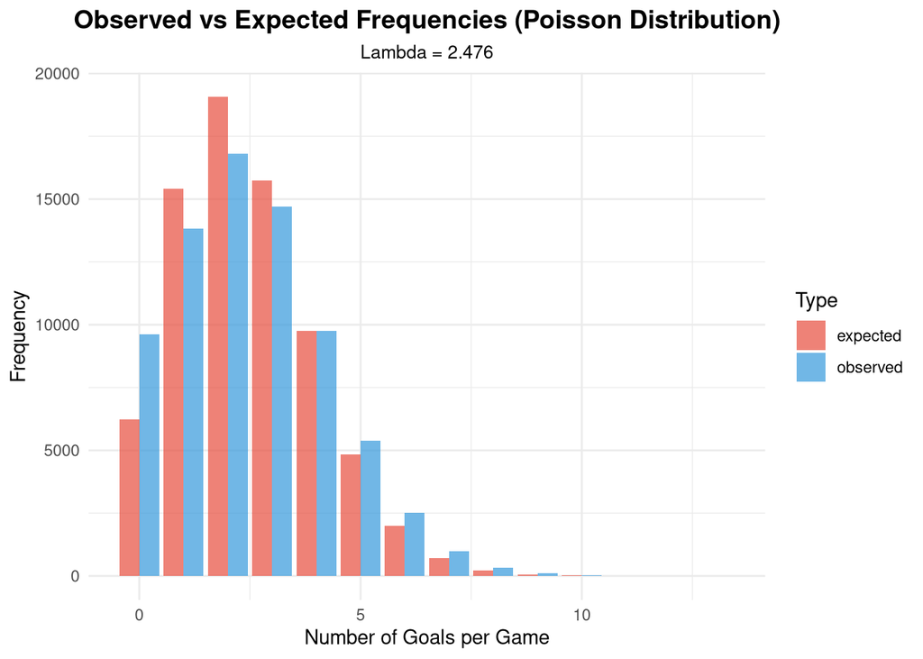

```r
# Observed vs Expected frequencies
comparison_long <- comparison %>%
  dplyr::select(goals_count, observed, expected) %>%
  tidyr::pivot_longer(cols = c(observed, expected), names_to = "type", values_to = "frequency")

ggplot(comparison_long, aes(x = goals_count, y = frequency, fill = type)) +
  geom_bar(stat = "identity", position = "dodge", alpha = 0.7) +
  labs(
    title = "Observed vs Expected Frequencies (Poisson Distribution)",
    subtitle = paste("Lambda =", round(lambda, 3)),
    x = "Number of Goals per Game",
    y = "Frequency",
    fill = "Type"
  ) + theme_minimal() + theme(plot.title = element_text(hjust = 0.5, size = 14, face = "bold"), plot.subtitle = element_text(hjust = 0.5, size = 10)) +
  scale_fill_manual(values = c("observed" = "#3498DB", "expected" = "#E74C3C"))
```

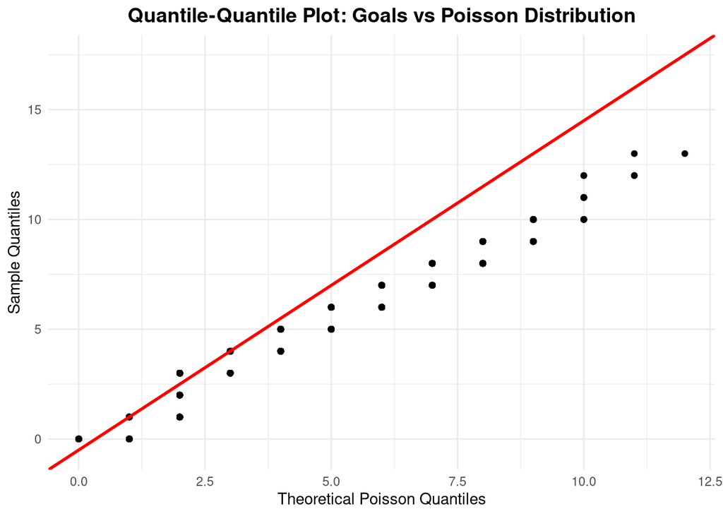

```r
ggplot(all_games, aes(sample = goals_count)) +
  stat_qq(distribution = qpois, dparams = list(lambda = lambda)) +
  stat_qq_line(distribution = qpois, dparams = list(lambda = lambda),
               color = "red", size = 1) +
  labs(title = "Quantile-Quantile Plot: Goals vs Poisson Distribution", x = "Theoretical Poisson Quantiles", y = "Sample Quantiles") +
  theme_minimal() +
  theme(plot.title = element_text(hjust = 0.5, size = 14, face = "bold"))
```

```r
cat("Statistical analysis\n")
```

```
## Statistical analysis
```

```r
cat("Hypothesis test results:\n")
```

```
## Hypothesis test results:
```

```r
cat("Chi-square Test:\n")
```

```
## Chi-square Test:
```

```r
cat("Statistic: ", chi_test$statistic, "\n")
```

```
## Statistic:  2718.04
```

```r
cat("Degrees of Freedom: ", chi_test$parameter, "\n")
```

```
## Degrees of Freedom:  6
```

```r
cat("P-value: ", format(chi_test$p.value, scientific = TRUE), "\n\n")
```

```
## P-value:  0e+00
```

```r
cat("Kolmogorov-Smirnov Test:\n")
```

```
## Kolmogorov-Smirnov Test:
```

```r
cat("D Statistic: ", round(ks_test$statistic, 4), "\n")
```

```
## D Statistic:  0.2334
```

```r
cat("P-value: ", format(ks_test$p.value, scientific = TRUE), "\n\n")
```

```
## P-value:  0e+00
```

```r
cat("Conclusion\n")
```

```
## Conclusion
```

```r
cat("The data does not follow a Poisson distribution.\n")
```

```
## The data does not follow a Poisson distribution.
```

```r
cat("Both statistical tests reject the null hypothesis (p-values < 0.05).\n\n")
```

```
## Both statistical tests reject the null hypothesis (p-values < 0.05).
```

```r
cat("Though the bar chart shows rough alignment between observed and expected.\n")
```

```
## Though the bar chart shows rough alignment between observed and expected.
```

```r
cat("Unfortunately even small deviations on big sample sizes are significant.\n")
```

```
## Unfortunately even small deviations on big sample sizes are significant.
```

```r
cat("Mean goals per game: ", round(lambda, 3), "\n")
```

```
## Mean goals per game:  2.476
```

```r
cat("Variance: ", round(var(all_games$goals_count), 3), "\n")
```

```
## Variance:  2.998
```

```r
cat("Variance/Mean: ", round(var(all_games$goals_count) / lambda, 3), "\n")
```

```
## Variance/Mean:  1.211
```

```r
cat("In case of Poisson distribution, variance should equal to the mean.\n")
```

```
## In case of Poisson distribution, variance should equal to the mean.
```

```r
cat("While the Poisson distribution helps demonstrate general shape of goal scoring\n")
```

```
## While the Poisson distribution helps demonstrate general shape of goal scoring
```

```r
cat("the deviations indicate that real-world football goal\n")
```

```
## the deviations indicate that real-world football goal
```

```r
cat("distributions vary severely more than the Poisson model predicts.\n\n")
```

```
## distributions vary severely more than the Poisson model predicts.
```

```r
cat("The extremely small p-values (< 2.2e-16) is a very strong evidence to reject\n")
```

```
## The extremely small p-values (< 2.2e-16) is a very strong evidence to reject
```

```r
cat("the hypothesis about Poisson distribution, despite the visually acceptable fit.\n\n")
```

```
## the hypothesis about Poisson distribution, despite the visually acceptable fit.
```

# Hypothesis 2: Players perform worse after certain age

[figure not shown]

```r
target_names <- "Lionel Messi|Cristiano Ronaldo|Zlatan Ibrahimović"

superstars_df <- appearances %>%
  filter(grepl(target_names, player, ignore.case = TRUE)) %>%
  filter(minutes_played > 45) %>%
  mutate(player_label = case_when(
    grepl("Lionel Messi", player) ~ "Lionel Messi",
    grepl("Cristiano Ronaldo", player) ~ "Cristiano Ronaldo",
    grepl("Zlatan Ibrahimović", player) ~ "Zlatan Ibrahimović",
    TRUE ~ player
  ))

superstars_anova <- superstars_df %>%
  mutate(career_stage = case_when(
    age_at_match < 35 ~ "Prime (Yonger than 35)",
    age_at_match >= 35 ~ "Veteran (35+)"
  ))

ggplot(superstars_anova, aes(x = career_stage, y = goals, fill = player_label)) +
  geom_boxplot(alpha = 0.5) +
  labs(
    title = "Performance by Age",
    subtitle = "Comparing Prime(<35) vs. Veteran (35+)",
    x = "Career Stage",
    y = "Goals + Assists per Match"
  ) +
  theme_minimal()
```

```r
model_superstar <- aov(goals ~ career_stage, data = superstars_anova)

cat("--- ANOVA Results for Superstars ---\n")
```

```
## --- ANOVA Results for Superstars ---
```

```r
summary(model_superstar)
```

```
##                Df Sum Sq Mean Sq F value   Pr(>F)
## career_stage    1   15.2  15.150   17.52 3.05e-05 ***
## Residuals    1172 1013.2   0.865
## ---
## Signif. codes:  0 '***' 0.001 '**' 0.01 '*' 0.05 '.' 0.1 ' ' 1
```

```r
cat("\n--- Detailed Comparison ---\n")
```

```
##
## --- Detailed Comparison ---
```

```r
TukeyHSD(model_superstar)
```

```
##   Tukey multiple comparisons of means
##     95% family-wise confidence level
##
## Fit: aov(formula = goals ~ career_stage, data = superstars_anova)
##
## $career_stage
##                                            diff        lwr        upr    p adj
## Veteran (35+)-Prime (Yonger than 35) -0.2876461 -0.4224597 -0.1528326 3.05e-05
```

### Explanation

Define the performance of a player as the #goals per match(given that the player spent at least 45 minutes playing in that match). Break down the data in two groups:

1. Prime: performance at younger age(<35 y.o.)
2. Veteran: performance at older age (35+ y.o)

By using the ANOVA test we can calculate the statistical difference between the average performance of two groups(and if is difference is due to noise or not).

The hypothesis is as follows:

$$H_0: \mu_{prime} = \mu_{veteran} \text{
vs. } H_1 : \mu_{prime} \ne \mu_{veteran}$$

From our data we get
$$p =
3.05e-05$$
, therefore we can reject
$$H_0$$
with great confidence.

After finding a statistical difference in data (meaning that indeed two groups perform diffirently), we use Tukey HSD to understand which group actually performs better and by how much.

The
$$diff$$
parameter in the test is equal to
$$-0.2876461 < 0$$
which tells us that the “Prime” group on average performs better(as we testes “Veteran”-“Prime”). The adjusted
$$p$$
value of
$$3.05e-05$$
confirms that the difference is statistically significant.

In conclusion we can say that the “Veteran” group performs worse by 0.28 Goals per game. Which in a 38-game season gives a difference of 10-11 goals.

It should be mentioned that the data-set consists of data from 2012 and onward, so technically the prime group is defined as:

Messi (25-34 y.o.)

Ronaldo (27-34 y.o.)

Ibrahimović (31-34 y.o.)

# Hypothesis 3: Seasonal performance

Our hypothesis is that players’ performance depends on year season

```r
players_of_interest <- c("Cristiano Ronaldo", "Lionel Messi", "Luka Modric", "Thomas Müller", "Neymar", "Kylian Mbappé")
appearances_of_interest <- filter(appearances, player %in% players_of_interest)
```

```r
appearances_of_interest <- appearances_of_interest %>%
  mutate(
    month   = month(date),
    year    = year(date),
    season  = case_when(
      month %in% c(12, 1, 2) ~ "Winter",
      month %in% c(3, 4, 5) ~ "Spring",
      month %in% c(6, 7, 8) ~ "Summer",
      month %in% c(9, 10, 11) ~ "Autumn",
      TRUE ~ NA_character_
    )
  )

player_season_stats <- appearances_of_interest %>%
  group_by(player, year, season) %>%
  summarise(
    games = n(),
    goals = sum(goals, na.rm = TRUE),
    assists = sum(assists, na.rm = TRUE),
    minutes = sum(minutes_played, na.rm = TRUE),
    avg_goals = (goals+assists)/games,
    .groups = "drop"
  ) %>%
  arrange(player, year, season)

player_yearly_stats <- appearances_of_interest %>%
  group_by(player, year) %>%
  summarise(
    games = n(),
    goals = sum(goals, na.rm = TRUE),
    assists = sum(assists, na.rm = TRUE),
    minutes = sum(minutes_played, na.rm = TRUE),
    avg_goals = (goals+assists) / games,
    .groups = "drop"
  )
```

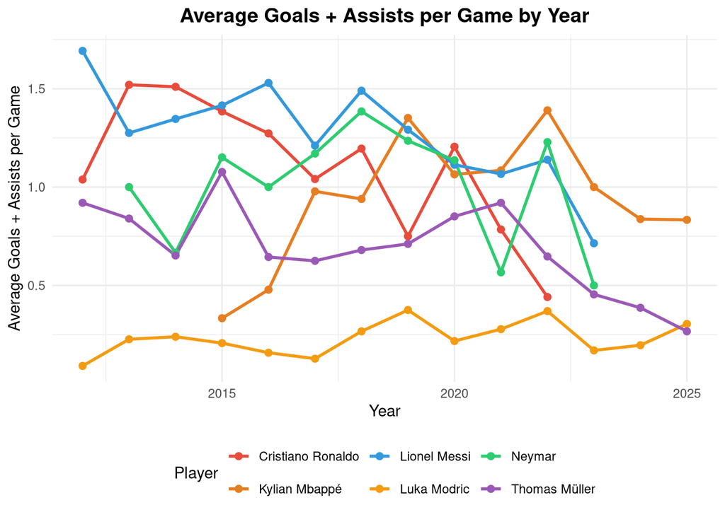

```r
# Create the line plot
ggplot(player_yearly_stats, aes(x = year, y = avg_goals, color = player)) +
  geom_line(size = 1) +
  geom_point(size = 2) +
  labs(
    title = "Average Goals + Assists per Game by Year",
    x = "Year",
    y = "Average Goals + Assists per Game",
    color = "Player"
  ) +
  theme_minimal() +
  theme(
    legend.position = "bottom",
    plot.title = element_text(hjust = 0.5, size = 14, face = "bold")
  ) +
  scale_color_manual(values = c(
    "Cristiano Ronaldo" = "#E74C3C",
    "Lionel Messi" = "#3498DB",
    "Luka Modric" = "#F39C12",
    "Thomas Müller" = "#9B59B6",
    "Neymar" = "#2ECC71",
    "Kylian Mbappé" = "#E67E22"
  ))
```

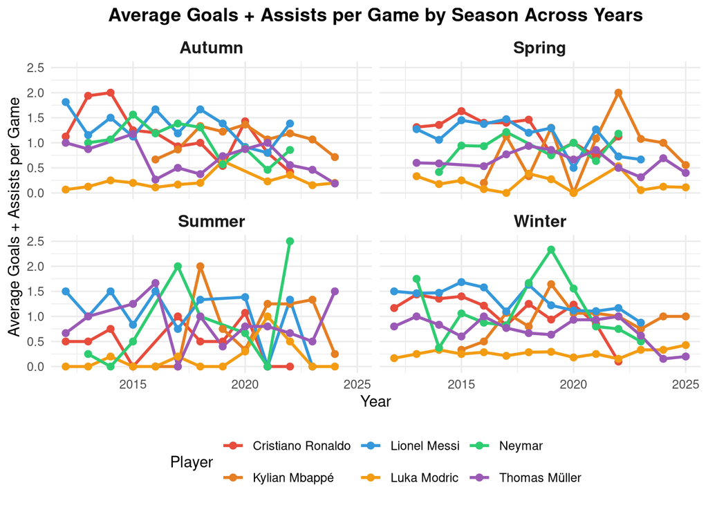

```r
# Create line plot with facets for each season
ggplot(player_season_stats, aes(x = year, y = avg_goals, color = player)) +
  geom_line(size = 1) +
  geom_point(size = 2) +
  facet_wrap(~ season, ncol = 2) +
  labs(
    title = "Average Goals + Assists per Game by Season Across Years",
    x = "Year",
    y = "Average Goals + Assists per Game",
    color = "Player"
  ) +
  theme_minimal() +
  theme(
    legend.position = "bottom",
    plot.title = element_text(hjust = 0.5, line = 14, face = "bold"),
    strip.text = element_text(face = "bold", size = 12)
  ) +
  scale_color_manual(values = c(
    "Cristiano Ronaldo" = "#E74C3C",
    "Lionel Messi" = "#3498DB",
    "Luka Modric" = "#F39C12",
    "Thomas Müller" = "#9B59B6",
    "Neymar" = "#2ECC71",
    "Kylian Mbappé" = "#E67E22"
  ))
```

In the plot above we see average number of `goals+assists per match` as measure of players’ performance and it’s values across years overall and grouped by season. The plots are messy and hard to analyze. Nevertheless, we might wee, that summer is of 4 seasons giving zeros, like having no data and then large peaks of 2 and 2.5 average statistics.

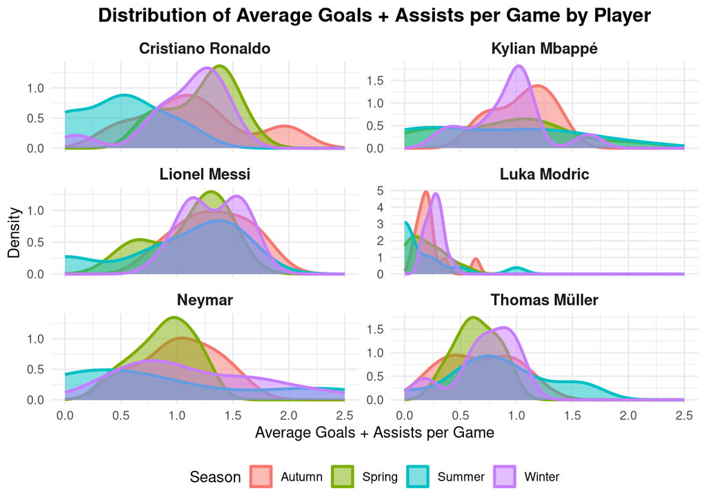

```r
ggplot(player_season_stats, aes(x = avg_goals, fill = season, color = season)) +
  geom_density(alpha = 0.5, size = 1) +
  facet_wrap(~ player, ncol = 2, scales = "free_y") +   # keep Y free but fix X
  coord_cartesian(xlim = c(0, 2.5)) +
  labs(
    title = "Distribution of Average Goals + Assists per Game by Player",
    x = "Average Goals + Assists per Game",
    y = "Density",
    fill = "Season",
    color = "Season"
  ) +
  theme_minimal() +
  theme(
    legend.position = "bottom",
    plot.title = element_text(hjust = 0.5, size = 14, face = "bold"),
    strip.text = element_text(face = "bold", size = 11)
  )
```

This plot look much cleaner and provides us with total emprical densities of seasonal performance for each player. These plots definitively show the extrime consistency of Lionel Messi throughout career at any season with a slight lower performance in summer and spring. Ronaldo also look dominant, however on summer he does not have season with average score >= 1.5 and has lot of 0.5 and 0 scores, which stands out of his performance during other seasons. Neymar show, that he both in summer and winter had all values of average performance from 0 to 2.5, yet more <1.0 on summer. More consistent on autumn and spring Luka Modric here is to point out, that average number of goals+assists is not the absolute measure of performance in football, as he is regarded as one of the best central midlfielder, yet scores so rarely. That is obviously because he is supposed to be defender, not the scorer

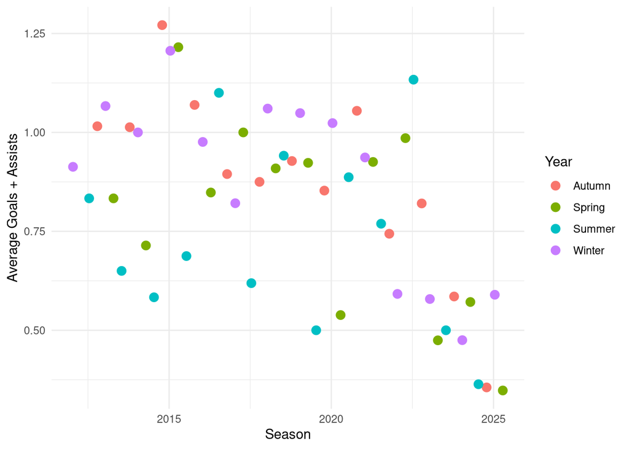

```r
df <- appearances_of_interest
# Ensure date column is Date type
df$date <- as.Date(df$date)

# Add year and season_period columns
df <- df %>%
  mutate(
    year = year(date),
    month = month(date)
  ) %>%
  arrange(date)

# Compute average goals+assists per season per year
season_summary <- df %>%
  group_by(year, season) %>%
  summarise(
    avg_goals_assists = mean(goals + assists, na.rm = TRUE),
    .groups = "drop"
  ) %>%
  # Add a representative date for plotting
  mutate(season_date = case_when(
    season == "Winter" ~ as.Date(paste0(year, "-01-15")),
    season == "Spring" ~ as.Date(paste0(year, "-04-15")),
    season == "Summer" ~ as.Date(paste0(year, "-07-15")),
    season == "Autumn" ~ as.Date(paste0(year, "-10-15"))
  ))

# Plot
ggplot(season_summary, aes(x = season_date, y = avg_goals_assists, color = factor(season))) +
  geom_point(size = 3) +
  labs(x = "Season", y = "Average Goals + Assists", color = "Year") +
  theme_minimal()
```

Here we see out mean statistic across season on y-axis, and date on x-axis, and each season is colored differently. Here we see, that performance differs from year, to year, but stays close to each other across seasons(for 2016-2023 it is $\approx1.0$). However summer stands out with lower values the average that year. Is it statistically significant? Also the plot shows, that performance it stable at about 0.9 till 2023, but after it drops significantly. Supposedly because of the lack of data, as it first showed not data on Ronaldo after 2022 and some others.

```r
# Run ANOVA
anova_model <- aov(avg_goals_assists ~ season, data = season_summary)

# Show summary
summary(anova_model)
```

```
##             Df Sum Sq Mean Sq F value Pr(>F)
## season       3 0.2004 0.06679   1.207  0.317
## Residuals   49 2.7118 0.05534
```

```r
# Post-hoc pairwise comparison (if significant)
TukeyHSD(anova_model)
```

```
##   Tukey multiple comparisons of means
##     95% family-wise confidence level
##
## Fit: aov(formula = avg_goals_assists ~ season, data = season_summary)
##
## $season
##                       diff         lwr        upr     p adj
## Spring-Autumn -0.091787627 -0.33718179 0.15360654 0.7530836
## Summer-Autumn -0.147100084 -0.39249425 0.09829408 0.3913364
## Winter-Autumn -0.005352459 -0.24632475 0.23561983 0.9999249
## Summer-Spring -0.055312456 -0.30070662 0.19008171 0.9317416
## Winter-Spring  0.086435168 -0.15453712 0.32740746 0.7759216
## Winter-Summer  0.141747625 -0.09922466 0.38271991 0.4080917
```

This is a test:
$$H_0: mean\ performance\
is\ the\ same\ in\ every\ season\\
H_1: mean\ differs$$
season shows how much of the data season explains and residulas shows how much it doesn’t. Residual is large. $Pr(>F)=0.317$ means, that there is 31.7% probability of seeing the data under $H_0$

next we see comparison and testing between individual seasons. The most important value is p adj, which means p_value of the same test with $H_0$ but for specified pair of seasons. The smallest values are indeed $Summer-Autumn$ and $Winter-Summer$, however they are still far from being statistically significant.